# Week 4

MACS 30405: Exploring Cultural Space  
University of Chicago

## Annoucement

- Readings for week 5 are released.

## Plan for coding exercises

- Exercise 1 (PCA): released on Mar 29; due on April 18
- Exercise 2 (FA/CA): released on April 12, due on April 18 (for FA) and/or 25 (for CA)
- Exercise 3 (Text analysis): to be released on April 17, due on May 2
  - If you have taken MACS 60000, next week’s content will be a bit repetitive. We can discuss about alternatives.

# Recap

## Factor analysis

- assumes that the data is generated from a few hidden dimensions and seeks to recover the dimensions
- Mathematical formulation:
  $$x_1 = \lambda_{11}f_1 + \lambda_{12}f_2 + ... + \lambda_{1m}f_m + e_1 \\
  x_2 = \lambda_{21}f_2 + \lambda_{22}f_2 + ... + \lambda_{2m}f_m + e_2 \\
  \vdots\\
  x_p = \lambda_{p1}f_2 + \lambda_{p2}f_2 + ... + \lambda_{pm}f_m + e_2 \\
  m < p$$
- The error terms are idiosyncratic and are uncorrelated among themselves and with any factor.
- The factors can be uncorrelated or correlated.

## Factor analysis via PCA approximation

1. Apply PCA to the dataset
2. Keep the first $m$ principal components scaled by the square roots of the eigenvalues and treat the rests as idiosyncratic.
3. Rotate the PC factors according to some criterion.

## Orthogoal rotation

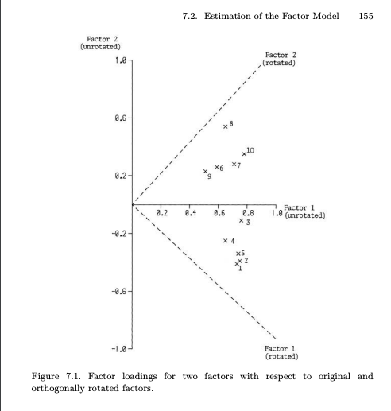

Jolliffe (2002, 155)

## Oblique rotation

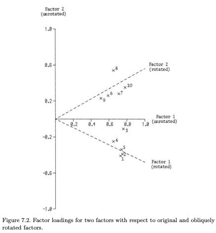

Jolliffe (2002, 156)

## PCA vs. FA

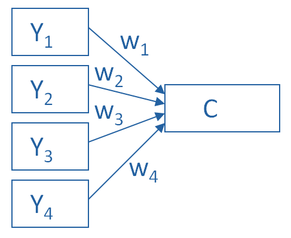

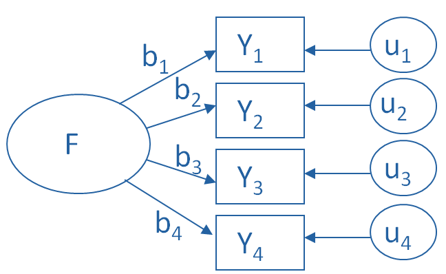

## Correspondence analysis

- Goal: given a count table $\mathbf{X} = [x_{ij}]$, to find row-weight and column-weight vectors $\mathbf{r} \in \mathbb{R}^n$ and $\mathbf{c} \in \mathbb{R}^p$, such that

$$\begin{equation}
\begin{aligned}
r_i &\propto \sum_{j=1}^p\ c_j \frac{x_{ij}}{x_{i\cdot}}, \\
\text{and } c_j &\propto \sum_{i=1}^n\ r_i \frac{x_{ij}}{x_{\cdot j}},
\end{aligned}
\end{equation}$$
where $x_{i\cdot}$ and $x_{\cdot j}$ are the sums of the $i$th row and the $j$th column, respectively.

## Basic Intuition

- The rows and columns are mutually defined in the same space.
  - A row is represented by its weight on all the columns. (A person’s cultural taste is defined by the genres he/she likes.)
  - A column is represented by the contribution of all the rows. (The taste of a genre is represented by the people who like it.)
  - All positions are estimated at once through matrix decomposition.

## Multiple correspondence analysis

- is an extension of CA that applies to multiple categorical variables.
- MCA starts with turning individual-level data into an indicator matrix:

## Indicator matrix

|  | … | Student | … | Engineer | … | Comedy | … | Sci-fi |
| --- | --- | --- | --- | --- | --- | --- | --- | --- |
| Individual 1 | … | 1 | … | 0 | … | 1 | … | 0 |
| … | … | … | … | … | … | … | … | … |
| Individual $n$ | … | 0 | … | 1 | … | 0 | … | 1 |

# Coding in Class

# Break

# Let’s talk about measurement.

## Discussion

- What is the distinction between “deliberative” and “non-deliberative” cognition?
- What types of measurement better capture each type of cognition?

## We will discuss more about using texts as a method next time.

## Goldberg & Stein (2018)

- How could global cultural patterns emerge without close interaction?
- Where does dimensional come from?